# Problem Set 3

Author

Jialiang Wu

For source files and data, see my GitHub repo: [STATS-506-Problem-Sets-03](https://github.com/CrispyShyYi/STATS-506-Problem-Sets/tree/main/set-3)

## Set up

```r
library(knitr)
library(dplyr)
library(haven) # xpt data set
library(pscl)
library(RSQLite)
library(DBI)
library(microbenchmark)
library(stringr)
library(ggplot2)
```

## Question 1

### question 1-a

load two data sets and inner merge.

```r
aux <- haven::read_xpt("AUX_I.xpt")
demo <- haven::read_xpt("DEMO_I.xpt")

# check the SEQN is unique
stopifnot(n_distinct(demo$SEQN) == nrow(demo))
stopifnot(n_distinct(aux$SEQN)  == nrow(aux))

# merge
merged <- demo %>% inner_join(aux, by = "SEQN")

cat("num of rows of DEMO_I:", nrow(demo), "\n")
```

```
num of rows of DEMO_I: 9971
```

```r
cat("num of rows of AUX_I:", nrow(aux),  "\n")
```

```
num of rows of AUX_I: 4582
```

```r
cat("num of merged `data.frame`:", nrow(merged), "\n")
```

```
num of merged `data.frame`: 4582
```

### question 1-b

In this case, there is a special column: INDHHIN2 - Annual household income. I decided to seperate into two groups: `Under $20,000` and `$20,000 and Over`, which could include all the data.

```r
# convert to category according to the doc
cleaned <- merged %>%
  transmute(
    # targets
    Tympanometric_width_of_right_ear = AUXTWIDR,
    Tympanometric_width_of_left_ear = AUXTWIDL,

    # predictors
    # Gender (1=Male, 2=Female)
    Gender = factor(RIAGENDR,
                    levels = c(1, 2),
                    labels = c("Male", "Female")),

    # Citizenship (1=Citizen by birth or naturalization, 2=Not a citizen of the US)
    Citizenship = na_if(DMDCITZN, 7),   # 7 = Refused
    Citizenship = na_if(Citizenship, 9), # 9 = Don't know
    Citizenship = factor(Citizenship,
                         levels = c(1, 2),
                         labels = c("US Citizen (birth/naturalization)",
                                    "Not a citizen of the US")),

    # Number of children 5 years or younger in the household ('0'=0, '1'=1, '2'=2, '3'=3 or more)
    Num5Children = factor(DMDHHSZA,
                         levels = c(0, 1, 2, 3),
                         labels = c("0", "1", "2", "3 or more")),

    # Annual household income (INDHHIN2)
    AnnualHouseIncome = case_when(
      INDHHIN2 %in% c(1, 2, 3, 4, 13) ~ "Under $20,000",
      INDHHIN2 %in% c(5, 6, 7, 8, 9, 10, 14, 15, 12) ~ "$20,000 and Over",
      INDHHIN2 %in% c(77, 99) ~ NA_character_,  # Refused / Don't know -> NA
      TRUE ~ NA_character_                      # missing -> NA
    ),
    AnnualHouseIncome = factor(AnnualHouseIncome,
                          levels = c("Under $20,000", "$20,000 and Over"))
  )

# check cleaned dataframe
str(cleaned)
```

```
tibble [4,582 × 6] (S3: tbl_df/tbl/data.frame)
 $ Tympanometric_width_of_right_ear: num [1:4582] 49 83 110 99 73 99 122 69 63 78 ...
  ..- attr(*, "label")= chr "Tympanometric width, right ear"
 $ Tympanometric_width_of_left_ear : num [1:4582] 76 51 49 116 73 70 111 73 60 88 ...
  ..- attr(*, "label")= chr "Tympanometric width, left ear"
 $ Gender                          : Factor w/ 2 levels "Male","Female": 1 1 2 2 1 2 1 1 1 2 ...
 $ Citizenship                     : Factor w/ 2 levels "US Citizen (birth/naturalization)",..: 1 2 1 1 1 2 1 1 1 1 ...
 $ Num5Children                    : Factor w/ 4 levels "0","1","2","3 or more": 1 1 1 1 1 2 1 1 1 1 ...
 $ AnnualHouseIncome               : Factor w/ 2 levels "Under $20,000",..: 2 1 2 2 2 2 1 1 2 2 ...
```

### question 1-c

```r
# transfer Num5Children and AnnualHouseIncome to continuous
cleaned <- cleaned %>%
  mutate(
    # Num5Children to int
    Num5Children_n = case_when(
      Num5Children == "0" ~ 0,
      Num5Children == "1" ~ 1,
      Num5Children == "2" ~ 2,
      Num5Children == "3 or more" ~ 3,
      TRUE ~ NA_real_
    ),
    # AnnualHouseIncome to int
    AnnualHouseIncome_n = case_when(
      AnnualHouseIncome == "Under $20,000" ~ 0,
      AnnualHouseIncome == "$20,000 and Over" ~ 1,
      TRUE ~ NA_real_
    )
  )

# Poisson regression model 1 - Right ear: gender
R1 <- glm(
  Tympanometric_width_of_right_ear ~ Gender,
  family = poisson(link = "log"),
  data = cleaned
)
summary(R1)
```

```
Call:
glm(formula = Tympanometric_width_of_right_ear ~ Gender, family = poisson(link = "log"),
    data = cleaned)

Coefficients:
             Estimate Std. Error  z value Pr(>|z|)
(Intercept)  4.434588   0.002468 1796.797  < 2e-16 ***
GenderFemale 0.009264   0.003380    2.741  0.00613 **
---
Signif. codes:  0 '***' 0.001 '**' 0.01 '*' 0.05 '.' 0.1 ' ' 1

(Dispersion parameter for poisson family taken to be 1)

    Null deviance: 70970  on 4148  degrees of freedom
Residual deviance: 70963  on 4147  degrees of freedom
  (433 observations deleted due to missingness)
AIC: 96618

Number of Fisher Scoring iterations: 4
```

```r
# Poisson regression model 2 - Right ear: gender, citizenship status (as categorical), number of children (as continuous), annual household income (as continuous)
R2 <- glm(
  Tympanometric_width_of_right_ear ~ Gender + Citizenship + Num5Children_n + AnnualHouseIncome_n,
  family = poisson(link = "log"),
  data = cleaned
)
summary(R2)
```

```
Call:
glm(formula = Tympanometric_width_of_right_ear ~ Gender + Citizenship +
    Num5Children_n + AnnualHouseIncome_n, family = poisson(link = "log"),
    data = cleaned)

Coefficients:
                                     Estimate Std. Error z value Pr(>|z|)
(Intercept)                         4.4378420  0.0047561 933.091  < 2e-16 ***
GenderFemale                        0.0147348  0.0035013   4.208 2.57e-05 ***
CitizenshipNot a citizen of the US  0.0771245  0.0044005  17.526  < 2e-16 ***
Num5Children_n                      0.0008283  0.0026163   0.317    0.752
AnnualHouseIncome_n                -0.0256096  0.0045113  -5.677 1.37e-08 ***
---
Signif. codes:  0 '***' 0.001 '**' 0.01 '*' 0.05 '.' 0.1 ' ' 1

(Dispersion parameter for poisson family taken to be 1)

    Null deviance: 66642  on 3885  degrees of freedom
Residual deviance: 66274  on 3881  degrees of freedom
  (696 observations deleted due to missingness)
AIC: 90311

Number of Fisher Scoring iterations: 4
```

```r
# Poisson regression model 3 - Left ear: gender
L1 <- glm(
  Tympanometric_width_of_left_ear ~ Gender,
  family = poisson(link = "log"),
  data = cleaned
)
summary(L1)
```

```
Call:
glm(formula = Tympanometric_width_of_left_ear ~ Gender, family = poisson(link = "log"),
    data = cleaned)

Coefficients:
             Estimate Std. Error  z value Pr(>|z|)
(Intercept)  4.439805   0.002473 1795.263  < 2e-16 ***
GenderFemale 0.012952   0.003387    3.824 0.000131 ***
---
Signif. codes:  0 '***' 0.001 '**' 0.01 '*' 0.05 '.' 0.1 ' ' 1

(Dispersion parameter for poisson family taken to be 1)

    Null deviance: 73307  on 4102  degrees of freedom
Residual deviance: 73293  on 4101  degrees of freedom
  (479 observations deleted due to missingness)
AIC: 98685

Number of Fisher Scoring iterations: 4
```

```r
# Poisson regression model 4 - Left ear: gender, citizenship status (as categorical), number of children (as continuous), annual household income (as continuous)
L2 <- glm(
  Tympanometric_width_of_left_ear ~ Gender + Citizenship + Num5Children_n + AnnualHouseIncome_n,
  family = poisson(link = "log"),
  data = cleaned
)
summary(L2)
```

```
Call:
glm(formula = Tympanometric_width_of_left_ear ~ Gender + Citizenship +
    Num5Children_n + AnnualHouseIncome_n, family = poisson(link = "log"),
    data = cleaned)

Coefficients:
                                    Estimate Std. Error z value Pr(>|z|)
(Intercept)                         4.471464   0.004742 942.856  < 2e-16 ***
GenderFemale                        0.015469   0.003509   4.408 1.04e-05 ***
CitizenshipNot a citizen of the US  0.044316   0.004449   9.962  < 2e-16 ***
Num5Children_n                     -0.017808   0.002645  -6.732 1.67e-11 ***
AnnualHouseIncome_n                -0.044617   0.004497  -9.921  < 2e-16 ***
---
Signif. codes:  0 '***' 0.001 '**' 0.01 '*' 0.05 '.' 0.1 ' ' 1

(Dispersion parameter for poisson family taken to be 1)

    Null deviance: 68282  on 3846  degrees of freedom
Residual deviance: 68024  on 3842  degrees of freedom
  (735 observations deleted due to missingness)
AIC: 91838

Number of Fisher Scoring iterations: 4
```

```r
# help function - get incidence risk ratios, N, AIC and pseudo-R^2
get_model_info <- function(model) {
  irr <- exp(coef(model))
  ci <- exp(confint(model))
  tibble(
    term = names(irr),
    IRR = irr,
    CI_low = ci[,1],
    CI_high = ci[,2]
  ) %>%
    mutate(
      N = nobs(model),
      AIC = AIC(model),
      PseudoR2 = pscl::pR2(model)["McFadden"]
    )
}

# get information
R1_res <- get_model_info(R1)
```

```
fitting null model for pseudo-r2
```

```r
R2_res <- get_model_info(R2)
```

```
fitting null model for pseudo-r2
```

```r
L1_res <- get_model_info(L1)
```

```
fitting null model for pseudo-r2
```

```r
L2_res <- get_model_info(L2)
```

```
fitting null model for pseudo-r2
```

```r
# combine information
all_results <- bind_rows(
  R1_res %>% mutate(Model = "Right ear - Gender"),
  R2_res %>% mutate(Model = "Right ear - Full"),
  L1_res %>% mutate(Model = "Left ear - Gender"),
  L2_res %>% mutate(Model = "Left ear - Full")
)

kable(all_results, digits = 3, caption = "Poisson regression results: Incidence Rate Ratios (IRR)")
```

Poisson regression results: Incidence Rate Ratios (IRR)

| term | IRR | CI_low | CI_high | N | AIC | PseudoR2 | Model |
| --- | --- | --- | --- | --- | --- | --- | --- |
| (Intercept) | 84.317 | 83.910 | 84.726 | 4149 | 96618.48 | 0.000 | Right ear - Gender |
| GenderFemale | 1.009 | 1.003 | 1.016 | 4149 | 96618.48 | 0.000 | Right ear - Gender |
| (Intercept) | 84.592 | 83.807 | 85.384 | 3886 | 90311.36 | 0.004 | Right ear - Full |
| GenderFemale | 1.015 | 1.008 | 1.022 | 3886 | 90311.36 | 0.004 | Right ear - Full |
| CitizenshipNot a citizen of the US | 1.080 | 1.071 | 1.090 | 3886 | 90311.36 | 0.004 | Right ear - Full |
| Num5Children_n | 1.001 | 0.996 | 1.006 | 3886 | 90311.36 | 0.004 | Right ear - Full |
| AnnualHouseIncome_n | 0.975 | 0.966 | 0.983 | 3886 | 90311.36 | 0.004 | Right ear - Full |
| (Intercept) | 84.758 | 84.348 | 85.170 | 4103 | 98685.15 | 0.000 | Left ear - Gender |
| GenderFemale | 1.013 | 1.006 | 1.020 | 4103 | 98685.15 | 0.000 | Left ear - Gender |
| (Intercept) | 87.485 | 86.674 | 88.301 | 3847 | 91838.35 | 0.003 | Left ear - Full |
| GenderFemale | 1.016 | 1.009 | 1.023 | 3847 | 91838.35 | 0.003 | Left ear - Full |
| CitizenshipNot a citizen of the US | 1.045 | 1.036 | 1.054 | 3847 | 91838.35 | 0.003 | Left ear - Full |
| Num5Children_n | 0.982 | 0.977 | 0.987 | 3847 | 91838.35 | 0.003 | Left ear - Full |
| AnnualHouseIncome_n | 0.956 | 0.948 | 0.965 | 3847 | 91838.35 | 0.003 | Left ear - Full |

### question 1-d

```r
# IRR
print("Coefficient of the L2 Model")
```

```
[1] "Coefficient of the L2 Model"
```

```r
exp(coef(L2))
```

```
                       (Intercept)                       GenderFemale
                        87.4846750                          1.0155892
CitizenshipNot a citizen of the US                     Num5Children_n
                         1.0453130                          0.9823500
               AnnualHouseIncome_n
                         0.9563634
```

```r
# confidence interval
print("Confidence Interval of the coefficients")
```

```
[1] "Confidence Interval of the coefficients"
```

```r
exp(confint(L2))
```

```
                                        2.5 %     97.5 %
(Intercept)                        86.6744521 88.3008365
GenderFemale                        1.0086290  1.0225986
CitizenshipNot a citizen of the US  1.0362303  1.0544593
Num5Children_n                      0.9772643  0.9874504
AnnualHouseIncome_n                 0.9479784  0.9648380
```

```r
# summary table
summary(L2)
```

```
Call:
glm(formula = Tympanometric_width_of_left_ear ~ Gender + Citizenship +
    Num5Children_n + AnnualHouseIncome_n, family = poisson(link = "log"),
    data = cleaned)

Coefficients:
                                    Estimate Std. Error z value Pr(>|z|)
(Intercept)                         4.471464   0.004742 942.856  < 2e-16 ***
GenderFemale                        0.015469   0.003509   4.408 1.04e-05 ***
CitizenshipNot a citizen of the US  0.044316   0.004449   9.962  < 2e-16 ***
Num5Children_n                     -0.017808   0.002645  -6.732 1.67e-11 ***
AnnualHouseIncome_n                -0.044617   0.004497  -9.921  < 2e-16 ***
---
Signif. codes:  0 '***' 0.001 '**' 0.01 '*' 0.05 '.' 0.1 ' ' 1

(Dispersion parameter for poisson family taken to be 1)

    Null deviance: 68282  on 3846  degrees of freedom
Residual deviance: 68024  on 3842  degrees of freedom
  (735 observations deleted due to missingness)
AIC: 91838

Number of Fisher Scoring iterations: 4
```

In Model 2L, gender has a significant effect on the Tympanometric width of the left ear. For females compared to males, the estimated log(IRR) is 0.015 (SE = 0.0035, z = 4.41, p < 0.001). Transformed to the incidence risk ratio scale, this corresponds to an IRR of 1.016, meaning that females have, on average, about a 1.6% higher expected Tympanometric width than males, after controlling for citizenship status, number of children, and annual household income.

## Question 2

connect db

```r
db_path <- "sakila_master.db"
sakila <- dbConnect(RSQLite::SQLite(), db_path)

# List tables
dbListTables(sakila)
```

```
 [1] "actor"                  "address"                "category"
 [4] "city"                   "country"                "customer"
 [7] "customer_list"          "film"                   "film_actor"
[10] "film_category"          "film_list"              "film_text"
[13] "inventory"              "language"               "payment"
[16] "rental"                 "sales_by_film_category" "sales_by_store"
[19] "staff"                  "staff_list"             "store"
```

### question 2-a

```r
# dive into customer table
dbListFields(sakila, "customer")
```

```
[1] "customer_id" "store_id"    "first_name"  "last_name"   "email"
[6] "address_id"  "active"      "create_date" "last_update"
```

```r
# use SQL get table, then use R
customer_df <- dbGetQuery(sakila, "SELECT customer_id, store_id, active FROM customer")
# check types
str(customer_df)
```

```
'data.frame':   599 obs. of  3 variables:
 $ customer_id: int  1 2 3 4 5 6 7 8 9 10 ...
 $ store_id   : int  1 1 1 2 1 2 1 2 2 1 ...
 $ active     : chr  "1" "1" "1" "1" ...
```

```r
approach_r_1 <- function() {
  customer_df <- dbGetQuery(
    sakila,
    "SELECT customer_id, store_id, active FROM customer"
  )
  customer_df %>%
    mutate(active_num = as.integer(active)) %>%   # "1"/"0" -> 1/0
    group_by(store_id) %>%
    summarise(
      total_customers  = n(),
      active_customers = sum(active_num, na.rm = TRUE),
      pct_active       = round(100 * mean(active_num, na.rm = TRUE), 2),
      .groups = "drop"
    ) %>%
    arrange(store_id)
}

# use SQL
approach_sql_1 <- function() {
  dbGetQuery(
    sakila,
    "
    SELECT
      store_id,
      COUNT(customer_id) AS total_customers,
      SUM(active) AS active_customers,
      ROUND(100.0 * SUM(active ) / COUNT(customer_id), 2) AS pct_active
    FROM customer
    GROUP BY store_id
    "
  )
}

# display results
res_r_1   <- approach_r_1()
res_sql_1 <- approach_sql_1()

print(res_r_1)
```

```
# A tibble: 2 × 4
  store_id total_customers active_customers pct_active
     <int>           <int>            <int>      <dbl>
1        1             326              318       97.6
2        2             273              266       97.4
```

```r
print(res_sql_1)
```

```
  store_id total_customers active_customers pct_active
1        1             326              318      97.55
2        2             273              266      97.44
```

```r
# microbenchmark comparison
microbenchmark(
  R_aggregate   = approach_r_1(),
  SQL_aggregate = approach_sql_1()
)
```

```
Unit: microseconds
          expr      min        lq      mean  median       uq      max neval
   R_aggregate 1783.172 1843.4420 2010.6224 1882.74 1969.804 4527.138   100
 SQL_aggregate  158.301  180.3795  198.9037  188.19  202.130  652.556   100
```

According to the benchmark comparision, the SQL run faster than the SQL + R strategy

### question 2-b

```r
# dive into corresponding tables
dbListFields(sakila, "staff")
```

```
 [1] "staff_id"    "first_name"  "last_name"   "address_id"  "picture"
 [6] "email"       "store_id"    "active"      "username"    "password"
[11] "last_update"
```

```r
dbListFields(sakila, "address")
```

```
[1] "address_id"  "address"     "address2"    "district"    "city_id"
[6] "postal_code" "phone"       "last_update"
```

```r
dbListFields(sakila, "city")
```

```
[1] "city_id"     "city"        "country_id"  "last_update"
```

```r
dbListFields(sakila, "country")
```

```
[1] "country_id"  "country"     "last_update"
```

```r
# SQL + R
approach_r_2 <- function() {
  staff_df   <- dbGetQuery(sakila, "SELECT staff_id, first_name, last_name, address_id FROM staff")
  address_df <- dbGetQuery(sakila, "SELECT address_id, city_id FROM address")
  city_df    <- dbGetQuery(sakila, "SELECT city_id, country_id FROM city")
  country_df <- dbGetQuery(sakila, "SELECT country_id, country FROM country")

  staff_country_r <- staff_df %>%
  inner_join(address_df, by = "address_id") %>%
  inner_join(city_df, by = "city_id") %>%
  inner_join(country_df, by = "country_id") %>%
  transmute(staff_name = paste(first_name, last_name),
            country)
}

# SQL
approach_sql_2 <- function() {
  dbGetQuery(
    sakila,
    "
    SELECT s.first_name || ' ' || s.last_name AS staff_name,
       ctry.country AS country
    FROM staff s
    INNER JOIN address a ON s.address_id = a.address_id
    INNER JOIN city c ON a.city_id = c.city_id
    INNER JOIN country ctry ON c.country_id = ctry.country_id
    "
  )
}

# display results
res_r_2   <- approach_r_2()
res_sql_2 <- approach_sql_2()

print(res_r_2)
```

```
    staff_name   country
1 Mike Hillyer    Canada
2 Jon Stephens Australia
```

```r
print(res_sql_2)
```

```
    staff_name   country
1 Mike Hillyer    Canada
2 Jon Stephens Australia
```

```r
# benchmark comparison
microbenchmark(
  R_aggregate   = approach_r_2(),
  SQL_aggregate = approach_sql_2()
)
```

```
Unit: microseconds
          expr      min       lq      mean   median        uq      max neval
   R_aggregate 2216.993 2240.055 2381.4698 2257.521 2285.1145 5517.124   100
 SQL_aggregate   99.384  104.714  115.3223  107.871  116.4605  520.618   100
```

According to the benchmark comparasion, the SQL run faster than the SQL + R strategy

### question 2-c

```r
# dive into corresponding tables
dbListFields(sakila, "film")
```

```
 [1] "film_id"              "title"                "description"
 [4] "release_year"         "language_id"          "original_language_id"
 [7] "rental_duration"      "rental_rate"          "length"
[10] "replacement_cost"     "rating"               "special_features"
[13] "last_update"
```

```r
dbListFields(sakila, "inventory")
```

```
[1] "inventory_id" "film_id"      "store_id"     "last_update"
```

```r
dbListFields(sakila, "rental")
```

```
[1] "rental_id"    "rental_date"  "inventory_id" "customer_id"  "return_date"
[6] "staff_id"     "last_update"
```

```r
dbListFields(sakila, "payment")
```

```
[1] "payment_id"   "customer_id"  "staff_id"     "rental_id"    "amount"
[6] "payment_date" "last_update"
```

```r
# SQL + R
approach_r_3 <- function() {
  film_df      <- dbGetQuery(sakila, "SELECT film_id, title FROM film")
  inventory_df <- dbGetQuery(sakila, "SELECT inventory_id, film_id FROM inventory")
  rental_df    <- dbGetQuery(sakila, "SELECT rental_id, inventory_id FROM rental")
  payment_df   <- dbGetQuery(sakila, "SELECT rental_id, amount FROM payment")

  film_rev <- film_df %>%
    inner_join(inventory_df, by = "film_id") %>%
    inner_join(rental_df,    by = "inventory_id") %>%
    inner_join(payment_df,   by = "rental_id") %>%
    group_by(film_id, title) %>%
    summarise(film_revenue = sum(amount, na.rm = TRUE), .groups = "drop")

  max_rev <- max(film_rev$film_revenue, na.rm = TRUE)

  top_films <- film_rev %>%
    filter(film_revenue == max_rev) %>%
    arrange(title)

  top_films
}

# SQL
approach_sql_3 <- function() {
  dbGetQuery(
    sakila,
    "
    SELECT f.title,
       SUM(p.amount) AS film_revenue
    FROM film f
    JOIN inventory i ON i.film_id = f.film_id
    JOIN rental    r ON r.inventory_id = i.inventory_id
    JOIN payment   p ON p.rental_id    = r.rental_id
    GROUP BY f.film_id, f.title
    HAVING SUM(p.amount) = (
      SELECT MAX(film_revenue)
      FROM (
        SELECT SUM(p2.amount) AS film_revenue
        FROM film f2
        JOIN inventory i2 ON i2.film_id = f2.film_id
        JOIN rental    r2 ON r2.inventory_id = i2.inventory_id
        JOIN payment   p2 ON p2.rental_id    = r2.rental_id
        GROUP BY f2.film_id
      )
    )
    ORDER BY f.title
    "
  )
}

# display results
res_r_3   <- approach_r_3()
res_sql_3 <- approach_sql_3()

print(res_r_3)
```

```
# A tibble: 1 × 3
  film_id title            film_revenue
    <int> <chr>                   <dbl>
1     879 TELEGRAPH VOYAGE         232.
```

```r
print(res_sql_3)
```

```
             title film_revenue
1 TELEGRAPH VOYAGE       231.73
```

```r
# benchmark comparison
microbenchmark(
  R_aggregate   = approach_r_3(),
  SQL_aggregate = approach_sql_3()
)
```

```
Unit: milliseconds
          expr      min       lq     mean   median       uq      max neval
   R_aggregate 13.61778 13.96850 14.52810 14.22167 14.60324 19.50046   100
 SQL_aggregate 39.66045 40.35812 41.27667 40.97101 41.74862 56.23175   100
```

According to the benchmark comparasion, the SQL + R strategy run faster than the SQL

## Question 3

set up data frame

```r
# load data set
Australia <- read.csv("au-500.csv")
```

### question 3-a

```r
# count web ends with ".com"
pattern <- "\\.com\\s*$"

is_com <- grepl(pattern, Australia$web, ignore.case = TRUE)
pct_com <- mean(is_com, na.rm = TRUE) * 100
cat("There is", pct_com, "% of websites are .com’s")
```

```
There is 0 % of websites are .com’s
```

### question 3-b

```r
Australia %>%
  count(domain = sub(".*@", "", email)) %>%
  arrange(desc(n)) %>%
  slice(1)
```

```
       domain   n
1 hotmail.com 114
```

According to the result, the hotmail.com is the most used domain

### question 3-c

```r
# contain a non-alphabetic character, excluding commas and whitespace
prop_non_alpha <- mean(str_detect(Australia$company_name, "[^A-Za-z,\\s]"))
cat("There are", prop_non_alpha * 100, "% company names contain a non-alphabetic character, excluding commas and whitespace\n")
```

```
There are 9 % company names contain a non-alphabetic character, excluding commas and whitespace
```

```r
# contain a non-alphabetic character, excluding commas, whitespace, and ampersands (“&”)
prop_non_alpha_no_amp <- mean(str_detect(Australia$company_name, "[^A-Za-z,\\s&]"))
cat("There are", prop_non_alpha_no_amp * 100, "% company names contain a non-alphabetic character, excluding commas, whitespace, and ampersands (“&”)\n")
```

```
There are 0.8 % company names contain a non-alphabetic character, excluding commas, whitespace, and ampersands (“&”)
```

### question 3-d

```r
Australia <- Australia %>%
  mutate(
    phone1 = gsub("-", "", phone1),  # get rid of '-'
    phone1 = sub("^(\\d{4})(\\d{3})(\\d{3})$", "\\1-\\2-\\3", phone1),
    phone2 = gsub("-", "", phone2),  # get rid of '-'
    phone2 = sub("^(\\d{4})(\\d{3})(\\d{3})$", "\\1-\\2-\\3", phone2),
  )

# check
head(Australia[, c("phone1", "phone2")], 10)
```

```
         phone1       phone2
1  0381-749-123 0458-665-290
2  0799-973-366 0497-622-620
3  0855-589-019 0427-885-282
4  0260-444-682 0443-795-912
5  0214-556-085 0453-666-885
6  0878-681-355 0451-966-921
7  0865-228-931 0427-991-688
8  0252-269-402 0415-961-606
9  0731-849-989 0411-732-965
10 0868-904-661 0461-862-457
```

### question 3-e

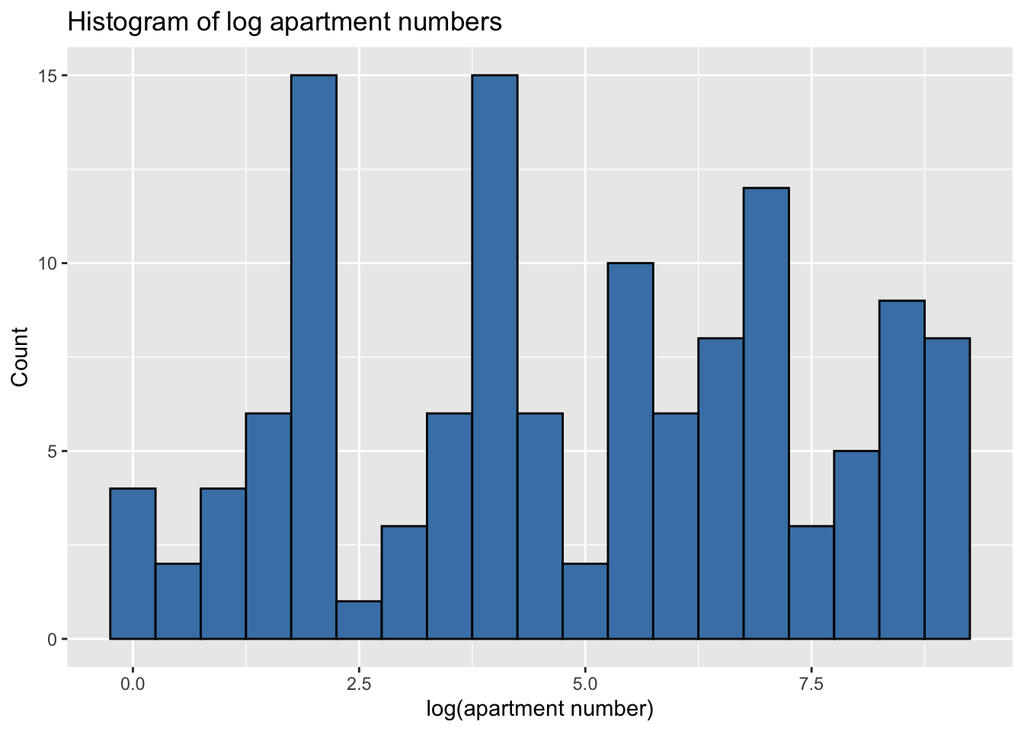

```r
Australia <- Australia %>%
  mutate(
    # extract apartment number after #
    # if there is no apartment number, keep as NA
    apartment_number = as.numeric(sub(".*#(\\d+)$", "\\1", address))
  )
# plot
Australia %>%
  filter(!is.na(apartment_number)) %>%
  ggplot(aes(x = log(apartment_number))) +
  geom_histogram(binwidth = 0.5, fill = "steelblue", color = "black") +
  labs(
    title = "Histogram of log apartment numbers",
    x = "log(apartment number)",
    y = "Count"
  )
```

### question 3-f

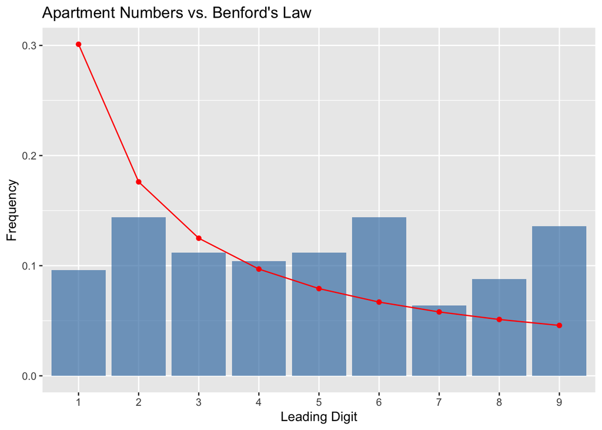

```r
# extract the first digit
benford_data <- Australia %>%
  filter(!is.na(apartment_number)) %>%
  mutate(leading_digit = as.numeric(substr(apartment_number, 1, 1))) %>%
  count(leading_digit) %>%
  mutate(freq = n / sum(n))

# theorem distribution
benford_theory <- data.frame(
  leading_digit = 1:9,
  prob = log10(1 + 1 / (1:9))
)

# visualization
ggplot() +
  geom_bar(data = benford_data, aes(x = factor(leading_digit), y = freq),
           stat = "identity", fill = "steelblue", alpha = 0.7) +
  geom_line(data = benford_theory, aes(x = factor(leading_digit), y = prob, group = 1),
            color = "red") +
  geom_point(data = benford_theory, aes(x = factor(leading_digit), y = prob),
             color = "red") +
  labs(
    title = "Apartment Numbers vs. Benford's Law",
    x = "Leading Digit",
    y = "Frequency"
  )
```

According to the visualization plot, the apartment number in this Austrilia - 500 data set doesn’t follow the Benford’s law. Instead, the leading digits are approximately uniform distributed. So I think the apartment number would not pass as real data.